# Efficient ODE Models with rodeo

Thomas Petzoldt

2017-06-30, 2019-02-14

Package **rodeo** (Kneis, Petzoldt, and Berendonk 2017; Kneis 2018) combines a series of complementary approaches to implement differential equation models (currently ODEs and 1D PDEs) in an efficient way:

1. The stoichiometry matrix notation ([Petersen matrix](https://en.wikipedia.org/wiki/Petersen_matrix))
2. A code generator to generate **R** or **Fortran** code from the tabular notation
3. Overhead-free access to forcing data from Fortran code,
4. Syntax for one-dimensional models, built-in integrator, documentation support.

A detailed description and tutorial can be found in the comprehensive [**rodeo package vignette**](https://CRAN.R-project.org/package=rodeo/vignettes/rodeoVignette.pdf) from [David Kneis](https://github.com/dkneis). The following example is served as a small teaser.

## A Predator-prey example

As a first example, we use a predator-prey model with three differential equations of the following form:

#### Resource (Substrate)

$$\frac{dS}{dt} = s_{in}(t) - b \cdot S \cdot P + g \cdot K$$

#### Prey (Producer)

$$\frac{dP}{dt} = c \cdot S \cdot P - d \cdot K \cdot P$$

#### Predator (Consumer)

$$\frac{dK}{dt} = e \cdot K \cdot P - f \cdot K$$

This is intentionally very basic, but we can see already, that the equations are coupled. As an example, the term $K \cdot P$, i.e. the interaction between prey and predator, appears twice, as a loss in the prey equation and as a gain in the predator equation. Only the rate constants $d$ and $e$ are different. A similar connection exists between resource and prey.

The obvious redundancy of terms (that can be much more complex for bigger models) can then be used to split the system of equations in two parts, a process vector and a stoichiometry matrix.

These two parts are essentially tables and can be organised as .csv-format or even in Excel (or LibreOffice) worksheets.

## Tabular model definition

In the following, we load the required packages, **readxl** for reading the tables, **deSolve** for the numerical solution of the equations and **rodeo** that creates an **R** (R Core Team 2018) or **Fortran** code from this. Package **rodeo** is implemented in the **R6** class system of **R**, we can see this from the `new` constructor and the dollar notation of the methods.

```r
library("readxl")
library("deSolve")
library("rodeo")
```

We load now the Excel tables to **R** and show its contents, but it is of course also a good idea to open the `model.xlsx`-file directly.

A typical **rodeo** model needs the following tables:

Tables `xstoi` and `forc` are optional and will be explained later. The last two lines in the following code convert the list of tables in the appropriate format. They are not necessary if we import the tables from .csv instead of xlsx.

```r
sheets <- c("vars", "pars", "funs", "pros", "stoi", "xstoi", "forc")

## read the tables
tables <- lapply(sheets, function(sheet) read_excel("model.xlsx", sheet = sheet))

## convert from read_xl specific "tibble" class to data.frame
tables <- lapply(tables, as.data.frame)
names(tables) <- sheets
```

## Now, let’s inspect the tables

```r
tables$vars
```

```
##   name unit             description default  rtol  atol tex html
## 1    S    - substrate concentration     1.0 1e-06 1e-06   S    S
## 2    P    -          prey abundance     1.0 1e-06 1e-06   P    P
## 3    K    -      predator abundance     0.5 1e-06 1e-06   K    K
```

```r
tables$pars
```

```
##       name unit                description default    tex           html
## 1 S_in_def    -        import of substrate     0.0 s_{in} S<sub>in</sub>
## 2        b    - substrate consumption rate     0.0      b              b
## 3        c    -           prey growth rate     0.1      c              c
## 4        d    -             prey loss rate     0.1      d              d
## 5        e    -       predator growth rate     0.1      e              e
## 6        f    -         predator loss rate     0.1      f              f
## 7        g    -     nutrient recyling rate     0.0      g              g
```

```r
tables$pros
```

```
##       name unit         description             expression        tex
## 1 s_import    - import of substrate (S_in(time, S_in_def))     s_{in}
## 2 p_growth    -      growth of prey                    S*P S \\cdot P
## 3 k_growth    -  growth of predator                    P*K P \\cdot K
## 4  k_death    -   death of predator                      K          K
```

The stoichiometry table can be given either datbase-like or as a cross table in matrix form. Both notations have their pros and cons. While database tables (`stoi` format) contain less redundancy and are easier to annotate, the interactions between state variables and processes are easier to follow in the crosstabular notation.

```r
tables$xstoi
```

```
##    process  K  P  S
## 1  k_death -f  0 +g
## 2 k_growth  e -d  0
## 3 p_growth  0  c -b
## 4 s_import  0  0  1
```

## Code generation and compile

Now we create the **rodeo** object by calling the constructor `new` with the given data frames from the `tables` list. The argument `dim=1` states that it is a box-model in 1 dimension, i.e. it is essentially zero dimensional.

```r
## create rodeo object
model <- with(tables,
  rodeo$new(vars=vars, pars=pars, funs=funs, pros=pros, stoi=stoi, dim=1))
```

The same can also be done from the cross-tabular form (argument: `asMatrix`). We only need to make sure that the column names contain all state variables and the row names all corresponding processes.

```r
xxstoi <- as.matrix(tables$xstoi[,-1])
rownames(xxstoi) <- tables$xstoi[,1]
model <- with(tables,
  rodeo$new(vars=vars, pars=pars, funs=funs, pros=pros, stoi=xxstoi,
            asMatrix=TRUE, dim=1)
)
```

As said, the example shown here is intentionally basic. However, it shows from the very beginning how to use external forcings, i.e. data read from an external file (see input.txt).

```r
tables$forc
##   name column mode      file default
## 1 S_in  input   -1 input.txt       1
```

If such functions (and of course also corresponding files) exist, an appropriate Fortran module can be generated with `forcingFunctions`:

```r
fforc <- forcingFunctions(tables$forc)
write(fforc, file = "forcings.f95")
```

Now we can compile the model, given that the R developer tools (**Rtools**) are installed. A second source file `functions.f95` contains additional formal definitions and (optionally) user-provided functions written directly in Fortran. It is therefore user-editable, while other parts (forcings and some includes taken directly from the package) should be left untouched.

```r
ret <- model$compile(sources  = c("forcings.f95", "functions.f95"))
```

## Model simulation

Now we are ready to assign parameters (`setPars`) and initial values (`setVars`) to run the model. Both, `vars` and `pars`must be **named** numeric vectors. They can be either taken from optional columns of the Excel tables or assigned separately (see 2nd scenario).

```r
vars <- setNames(tables$vars$default, tables$vars$name)
pars <- setNames(tables$pars$default, tables$pars$name)

model$setPars(pars)
model$setVars(vars)
```

The numerical solution is then carried out with function `dynamics` that calls an appropriate numerical solver from the **deSolve** (Soetaert, Petzoldt, and Setzer 2010b; Soetaert, Petzoldt, and Setzer 2010a) package. Now, let’s run some scenarios, a first scenario with the default parameter set:

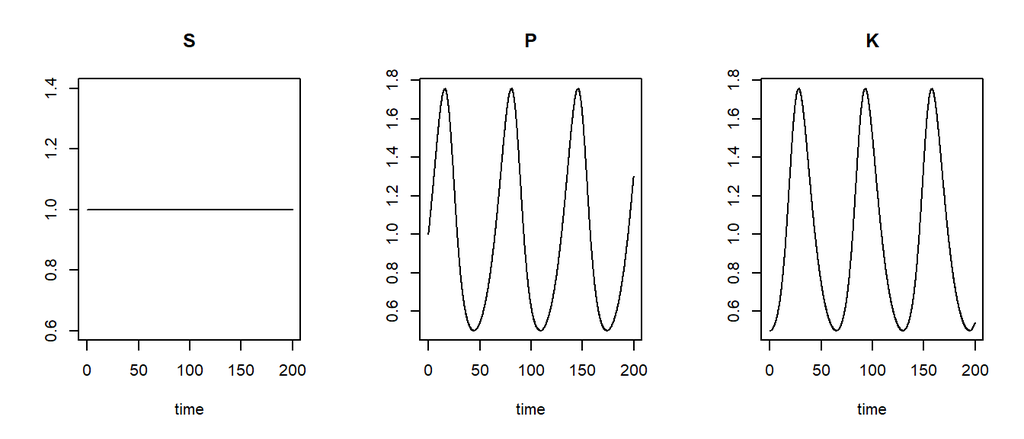

```r
out1 <- model$dynamics(seq(0, 200, 0.1))
plot(out1, which=c("S", "P", "K"), mfrow=c(1,3))
```

… a second scenario with a user-supplied parameter vector:

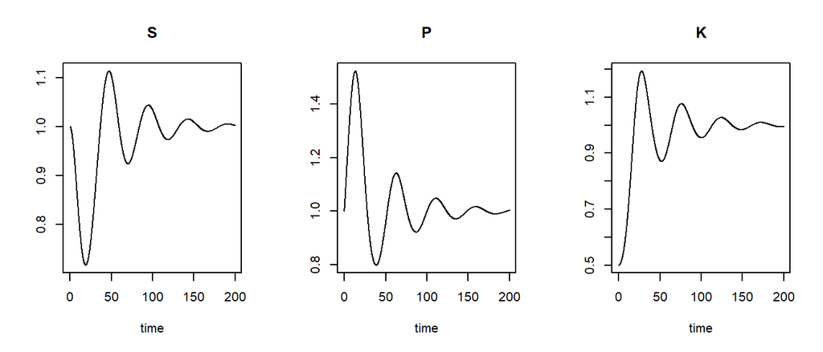

```r
pars <- c(S_in_def=0.1, b=0.1, c=0.1, d=0.1, e=0.1, f=0.1, g=0.0)
model$setPars(pars)
out2 <- model$dynamics(seq(0, 200, 0.1), method="bdf")
plot(out2, which=c("S", "P", "K"), mfrow=c(1, 3))
```

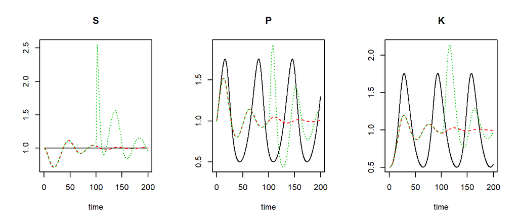

```r
pars <- c(S_in_def=NaN, b=0.1, c=0.1, d=0.1, e=0.1, f=0.1, g=0.0)
model$setPars(pars)
out3 <- model$dynamics(seq(0, 200, 0.1), method="bdf_d", hmax=1)
plot(out1, out2, out3, which=c("S", "P", "K"), mfrow=c(1,3))
```

## Controlling numerical precision

The precistion of **deSolve** solutions is controlled with two optional arguments `atol` and `rtol`. This is particular importance if scales of states differ, e.g. if a resource is in the range of 0.0001 while the bacteria may have an abundance of $10^9$.

As the table notation allows additional user-defined columns, individual state-variable dependent tolerances can be easily set.

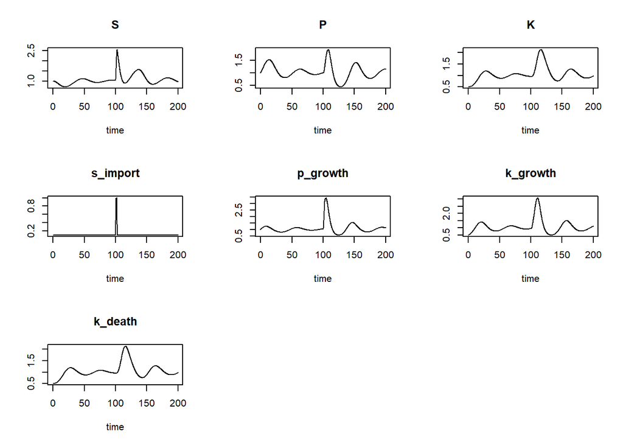

```r
pars <- c(S_in_def=NaN, b=0.1, c=0.1, d=0.1, e=0.1, f=0.1, g=0.0)
model$setPars(pars)
out4 <- model$dynamics(seq(0, 200, 0.1), method="bdf_d", hmax=1,
                       atol=tables$vars$atol, rtol=tables$vars$rtol)
plot(out4)
```

## Documentation support

The package contains several convenience functions, e.g. to visualize the stoichiometry matrix graphically or to export the parameter, variable, process and stoichiometry tables to Latex or HTML for documentation and publication.

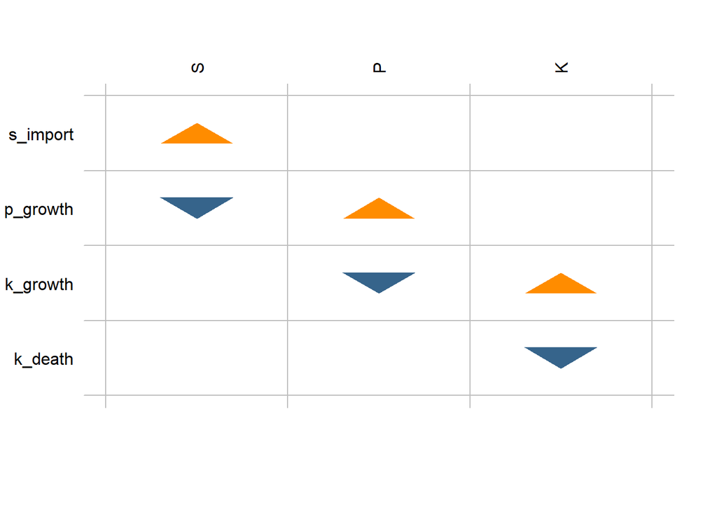

```r
model$plotStoichiometry(box=1)
```

```r
cat(exportDF(tables$pros[c("name", "unit", "expression", "tex")], tex=TRUE,
         funCell=c(name=function(x){paste0("\\textit{",x,"}")},
           tex=function(x){paste0("$",x,"$")})))
```

```
##   \begin{tabular}{llll}\hline
##     name & unit & expression & tex \\ \hline
##     \textit{s_import} & - & (S_in(time, S_in_def)) & $s_{in}$ \\
##     \textit{p_growth} & - & S*P & $S \cdot P$ \\
##     \textit{k_growth} & - & P*K & $P \cdot K$ \\
##     \textit{k_death} & - & K & $K$ \\ \hline
##   \end{tabular}
```

## Further reading

O.k., this was a first round. More technical background can be found in Kneis, Petzoldt, and Berendonk (2017), in the package the help files and in the extensive [rodeo package vignette](https://CRAN.R-project.org/package=rodeo/vignettes/rodeoVignette.pdf). And last but not least a web-based shiny examples, e.g. for a [shallow lake](http://limno-live.hydro.tu-dresden.de/models/shallowlake/) and [WebLAB](http://limno-live.hydro.tu-dresden.de/weblab/) demonstrate some more complex rodeo-models.

## References

Kneis, David. 2018. *rodeo: A Code Generator for Ode-Based Models*. https://CRAN.R-project.org/package=rodeo.

Kneis, David, Thomas Petzoldt, and Thomas U Berendonk. 2017. “An R-Package to Boost Fitness and Life Expectancy of Environmental Models.” *Environmental Modelling & Software* 96. Elsevier: 123–27. doi:10.1016/j.envsoft.2017.06.036.

R Core Team. 2018. *R: A Language and Environment for Statistical Computing*. Vienna, Austria: R Foundation for Statistical Computing. https://www.R-project.org/.

Soetaert, Karline, Thomas Petzoldt, and R. Woodrow Setzer. 2010a. “Solving Differential Equations in R.” *The R Journal* 2 (2): 5–15. https://journal.r-project.org/archive/2010-2/RJournal_2010-2_Soetaert~et~al.pdf.

———. 2010b. “Solving Differential Equations in R: Package deSolve.” *Journal of Statistical Software* 33 (9): 1–25. doi:10.18637/jss.v033.i09.

**Copyright and original author:** tpetzoldt, 2019-02-14